# Portfolio

Robert van Straten

10/02/2021

### Corpus description

The corpus I chose for my Computational Musicology portfolio is a selection of remixes of (pop) songs that I like. I’ve been maintaining a Spotify playlist, that now has around 75 remixed recordings, since last year. I started maintaining this playlist for myself because there are generally a lot of remixes for artists that I follow, but I was unfamiliar with most. Listening to a lot of remixes and collecting those that I like was an interesting musical journey.

It’d be interesting to find out if there’s some general elements shared among the remixed recordings that I like. Comparing the remixes to the original recordings can also be interesting, for sure the tempo would probably be higher for the remixes. The definition of a remix is sometimes confusing, but the ones on my playlist are either extended remixes by the original artists or a remix where a significant amount of production on the song has been altered from the original. Remixes where the only difference is a new guest artists are not included on the playlist.

The corpus is a personal playlist, artists on the playlist include Lady Gaga, Dua Lipa and Charli XCX, among others. Most of my music consumption takes place on Spotify, sometimes I watch a music video or performance on YouTube, or listen to one of the 40 albums I have collected on vinyl. Since the corpus is my personal playlist, it doesn’t fully cover the pop remixes genre, and there aren’t that many remixes of top 10 hits included.

**Typical tracks**:

1. Katy Perry - Chained To The Rhythm (Oliver Heldens Remix)
   - This is quite a typical pop remix, as there are lots on Spotify. Producers like Oliver Heldens, R3HAB and more just love to put these out. This is the type of remix that does no harm, but also doesn’t bring a lot (different) to the table.
2. Lady Gaga & Ariana Grande - Rain On Me (Purple Disco Machine Remix)
   - This is basically an extended version of the original, but the beat is a bit more house. There are more extended versions/remixes of tracks on this playlist, so it’s quite typical.

**Atypical tracks**:

1. Lady Gaga - Stupid Love (BloodPop® & BURNS Vitaclub Warehouse Remix)
   - This is almost an entirely different song from the original. It’s a lot more techno-adjacent and the structure is completely different.
2. Kesha - Praying (Frank Walker Remix)
   - This turns an acclaimed ballad into a dancefloor banger, with a good drop and build-ups. It may sound typical, but it feels so different and flips across genres.

### Plot 1 - Tempo

Tracks are remixed for a large amount of reasons, an important one being: the dancefloor. This means there is probably some change in tempo.

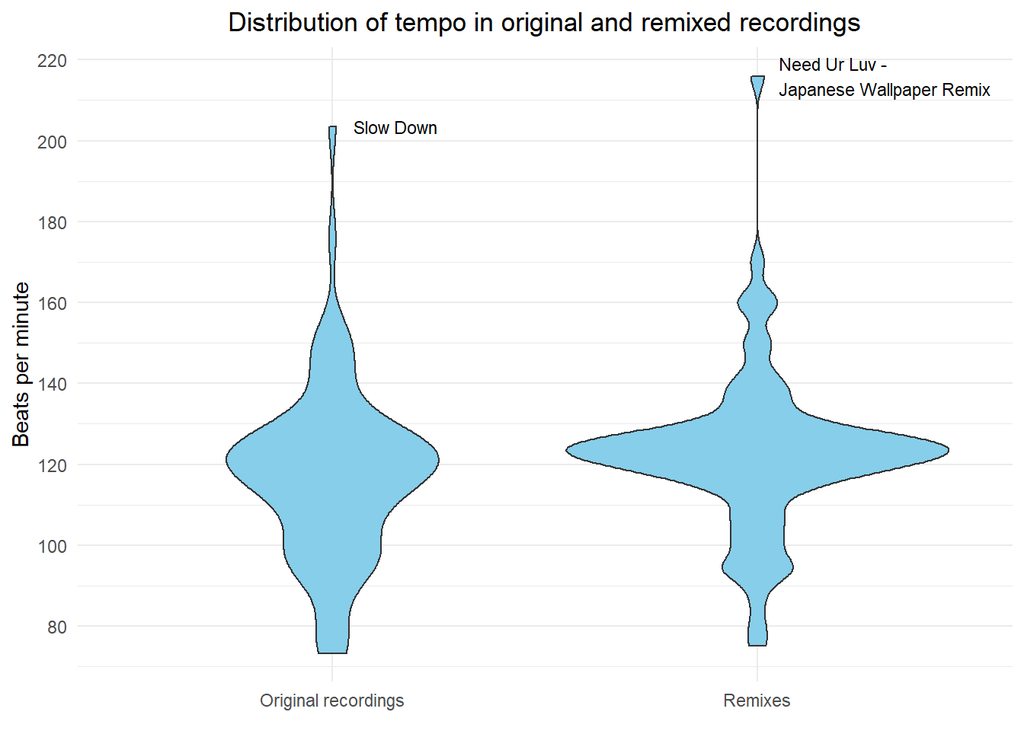

As can be seen in the violin plot, for original recordings, the tempo for most tracks lies between 100-140 bpm, with a peak around 120 bpm. The tempo for the remixed tracks are for more dense, with a peak just slightly higher than 120 bpm.

### Plot 2 - Club vibes

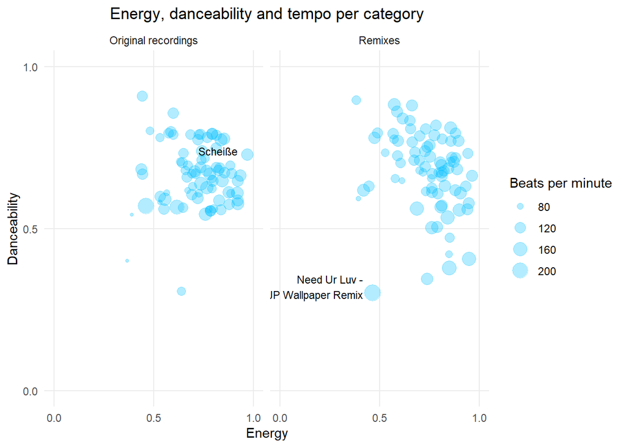

Seems like some remixes from my playlist make the original songs *less* danceable. It’s also fairly visible that most original recorings were already quite high in both energy and danceability, with almost all tracks being in the upper right quadrant. In general, the remixes do seem to have more energy. That doesn’t always make them more danceable, since quite a few more remixes are below 0.5 in danceability. Most less-danceable tracks seem to have a bpm higher than 120.

### Plot 3 - What changed?

It looks like energy can be quite different in remixes, so let’s look at the top 10 remixes that changed up the energy a lot.

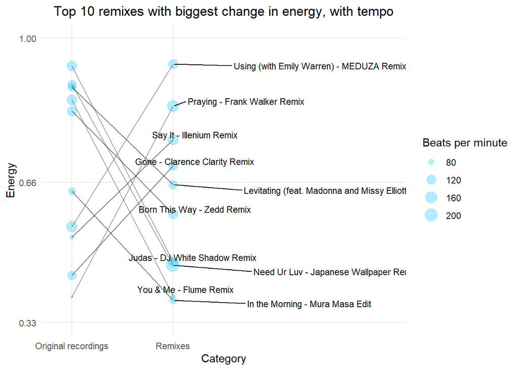

Those remixes are really quite different! But which remixes do barely change in energy?

Top 10 remixes with least change in energy, with duration change

| Remix | Energy | Change in energy from original | Change in duration (seconds) |
| --- | --- | --- | --- |
| Walking Away - Mura Masa Remix | 0.528 | -0.003 | 51.299 |
| Circus - Villains Remix | 0.739 | 0.006 | 125.200 |
| Simmer - Caroline Polachek Remix | 0.606 | 0.007 | -69.165 |
| You And I - SAINT WKND Remix | 0.793 | 0.007 | 14.937 |
| Flames - Extended | 0.717 | -0.009 | 96.702 |
| Better When You’re Gone - Extended Mix | 0.809 | 0.014 | 146.992 |
| OctaHate - Cashmere Cat Remix | 0.687 | 0.015 | 57.600 |
| Focus - Yaeji Remix | 0.614 | 0.016 | -4.187 |
| Don’t Start Now - Live in LA Remix | 0.810 | 0.017 | 156.785 |
| Toxic - Bloodshy & Avant’s Intoxicated Remix - 2009 Remaster | 0.855 | 0.017 | 136.400 |

The top 10 least changed remixes in terms of Spotify determined energy include several extended versions of songs (Circus, Flames, Better When You’re Gone, Don’t Start Now, and Toxic), it makes sense that an extended version of a song is not drastically different from the original.